# 숙련을 넘기면 무엇이 남는가

AI 에이전트에 암묵지를 넣는 근로계약 — 노동법 × 지식경영 × AI 거버넌스

저자

Insight Lab

공개

2026년 11월 15일

**노트핵심 문장**

작곡가의 곡과 작가의 글이 모델 학습의 원천이 되었을 때, 소송의 질문은 대체로 **누가 허락했고 누가 대가를 받는가**였다. 회사 안에서 20년 경력자가 예외 사례·실패 원인·멈춰야 할 조건을 AI 에이전트에 넘길 때도 질문은 같다. 다만 그 사람은 창작물을 납품한 외부 권리자가 아니라, 이미 고용관계 안에 있는 사람이다. 그래서 답은 “모든 업무 지식은 회사 것”도, “모든 경험은 개인 것”도 아니다. **숙련을 AI 자산으로 바꾸는 순간의 기여·용도·보상·책임을 계약 가능한 단위로 기록하는 것**이 답이다.

# 1 저작권의 질문이 사내 숙련으로 들어올 때

생성형 AI의 학습 데이터를 둘러싼 음악가·작가·신문사·이미지 창작자의 분쟁은 하나의 오해를 깨뜨렸다. 디지털 파일은 복사 비용이 낮다고 해서, 그 파일을 만든 사람의 이해관계까지 0이 되지는 않는다. 권리의 귀속, 허락의 범위, 출처의 추적, 재사용의 대가가 다시 논쟁의 중심이 됐다.

이 논점을 사내 AI로 옮기면 더 복잡해진다. 공정 엔지니어가 남긴 불량 대응 기록은 회사 설비·동료·데이터 없이 생기지 않았을 수 있다. 그러나 그 기록에 없는 “이 이상한 파형이면 우선 장비를 멈춰라”라는 판단은 개인의 실패 경험과 책임 감각에서 나왔을 수도 있다. 두 종류를 뭉뚱그려 **업무 산출물**이라고만 부르면, 나중에 에이전트가 누구의 숙련을 얼마나 재사용하는지 알 수 없다.

중요한 차이는 AI가 문서를 보관하는 데서 끝나지 않는다는 데 있다. 검색 시스템은 과거 기록을 찾아준다. 에이전트는 그 기록을 바탕으로 다음 행동을 제안하고, 반복 실행하며, 경우에 따라 원래 숙련자가 하던 판단의 일부를 대체한다. 지식의 전달은 곧 생산능력의 이전이 된다.

# 2 현행 제도는 어디까지 답하는가

한국 법에는 이미 가까운 원리가 있다. 근로기준법은 근로계약 시 임금·근로시간 등 근로조건을 명시하고 서면으로 교부하도록 한다. 취업규칙을 근로자에게 불리하게 바꾸는 경우에는 근로자 측 동의 절차를 요구한다. 발명진흥법은 직무발명의 권리를 사용자에게 승계하는 경우 종업원에게 정당한 보상권을 인정한다.

그러나 이 세 제도는 AI에 들어간 **암묵지의 재사용**을 직접 다루도록 설계된 것은 아니다. 직무발명은 특허 등으로 특정 가능한 결과를 전제하고, 근로조건 명시는 AI 전환의 기여 원장이나 재사용 이력을 자동으로 만들지 않는다. 그래서 새 권리를 당장 선언하기보다, 기존의 명시·동의·보상 원리를 AI 지식 전환 과정에 맞게 구체화해야 한다.

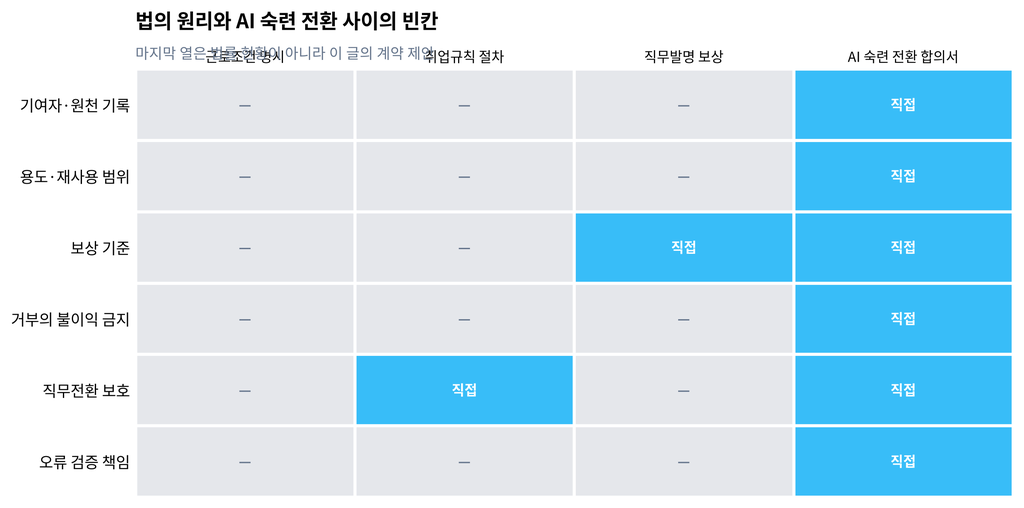

그림 1: 현행 제도와 제안 계약의 보호 항목 비교. 1은 해당 항목을 직접 다루거나 계약으로 즉시 구현할 수 있음을, 0은 직접 규율하지 않음을 뜻하는 규범 코딩이며, 실제 보호 수준이나 소송 승소 가능성을 측정한 통계가 아니다. 현행 열은 근로기준법 제17조·제94조와 발명진흥법 제15조의 조문 범위에 한정했다.

# 3 지식경영의 역설: 잘 남길수록 약해지는 사람

지식경영은 오랫동안 “암묵지를 문서로 바꾸라”고 말해 왔다. 조직은 퇴직·이동·사고에 대비하여 경험을 남기고 싶어 한다. AI 에이전트는 이 목표를 훨씬 싸고 빠르게 만든다. 대화로 추출하고, 사례로 연결하고, 새 질문에 맞추어 답하게 할 수 있기 때문이다.

그런데 여기에는 역설이 있다. 숙련자가 자신의 판단을 잘 넘길수록 자신의 협상력이 낮아지고, 자동화가 만든 이익은 조직만 가져간다면, 합리적인 노동자는 핵심 맥락을 남기지 않게 된다. 실패는 구두로만 전해지고, 예외 조건은 파일 밖에 남고, 시스템에는 안전한 일반론만 들어간다. 이것은 도덕성의 문제가 아니라 인센티브 설계의 문제다.

회사가 얻으려는 것은 결국 더 정확한 AI가 아니라 더 신뢰할 수 있는 조직 기억이다. 그러려면 지식 제공을 퇴직 전 인수인계나 일회성 데이터 입력으로 취급해서는 안 된다. AI가 재사용할 수 있게 만든 지식은 **별도 자산 전환 프로젝트**로 취급해야 한다.

# 4 제안: 근로계약서 하나가 아니라 두 층의 합의서

## 4.1 1층: 근로계약·취업규칙의 기본 원칙

기본 계약에는 회사의 기밀과 업무 산출물 보호 원칙을 유지하되, 다음을 넣는다.

1. 회사는 근로자의 경험·사례·판단 기준을 AI 시스템에 반영하려는 경우 목적, 이용 범위, 외부 모델 전송 여부, 재사용 기간, 검증 책임을 사전에 고지한다.
2. 개인 고유의 경력·개인 자료·업무 외에서 형성된 노하우를 학습 또는 재사용하려면 별도 합의를 원칙으로 한다.
3. 제공 또는 제공 거부를 이유로 불리한 처우를 하지 않는다.
4. AI 도입이 직무·보상·고용에 중대한 변화를 낳을 경우, 영향평가와 재배치·재훈련·보상 기준을 제시한다.

이 층은 전 직원에게 적용되는 안전망이다. 다만 이 조항만으로는 “누가 어느 AI에 무엇을 넣었는지”가 남지 않는다.

## 4.2 2층: 프로젝트별 ‘AI 숙련 전환 합의서’

실제 에이전트를 만들 때마다 짧은 별도 합의서를 쓴다. 핵심 필드는 여섯 개다.

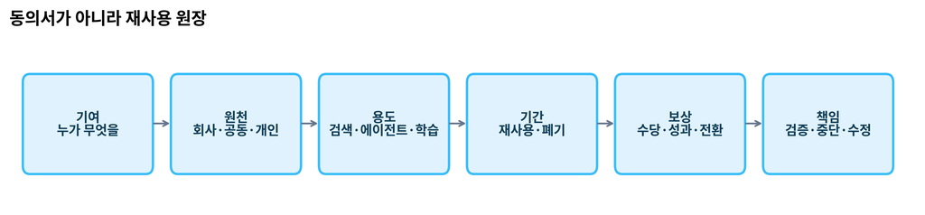

그림 2: AI 숙련 전환 합의서의 최소 원장. 계약서가 저장해야 할 것은 ‘업무 지식 제공에 동의한다’는 한 문장이 아니라, 나중에 재사용과 책임을 추적할 수 있는 여섯 필드다. 이는 제안 모형이다.

- **기여:** 어떤 사례, 검증, 인터뷰, 판단 규칙을 제공했는가.
- **원천:** 회사 데이터, 공동 작업, 개인 고유 경험이 각각 어느 정도 섞였는가.
- **용도:** 사내 검색인지, 업무 에이전트인지, 외부 모델 재학습인지.
- **기간:** 언제까지 쓰며, 퇴직·직무 이동 뒤에는 어떻게 처리하는가.
- **보상:** 구축 수당, 성과급, 교육시간, 직무 전환 기회 중 무엇을 제공하는가.
- **책임:** AI의 오류를 검토할 사람, 사용 중단을 요청할 권한, 수정 이력을 누가 맡는가.

이 방식은 모든 경험을 개인 소유로 만들자는 제안이 아니다. 회사 자산·공동으로 형성된 지식·개인 고유 숙련을 구분하고, 구분이 어려운 경우에는 기여와 재사용 범위를 투명하게 협의하자는 제안이다.

# 5 보상은 로열티 하나가 아니다

AI 숙련 전환의 보상을 무조건 영구 로열티로 설계하면 실행하기 어렵다. 반대로 일회성 문서 제출비만 주면, 에이전트가 만든 반복 수익과 개인의 기여가 완전히 분리된다. 조직별로 다음 조합이 더 현실적이다.

| 전환 형태 | 우선 보상 | 추가 보호 |
| --- | --- | --- |
| 매뉴얼·사례 정리 | 구축 기여 수당·유급 교육시간 | 기여 기록·원천 확인 |
| 반복 업무 에이전트 | 절감·성과 연동 보상 | 검증 책임 직무와 승급 경로 |
| 핵심 판단 규칙의 장기 재사용 | 기간형 보상 또는 직무수당 | 퇴직 후 재학습 제한·감사권 |
| 자동화로 직무 축소 가능 | 재배치·재훈련 우선권 | 전환 기간·최소 보호 기준 |

좋은 보상은 돈만이 아니다. 숙련을 제공한 사람이 더 낮은 자리로 밀려나지 않고 AI 운영·품질 검증·교육 역할로 이동할 수 있는 경로가 있어야 한다. 그렇지 않으면 조직은 가장 정확한 지식을 가진 사람에게 시스템을 가르친 뒤, 그 시스템의 결과를 검증할 사람을 잃는다.

# 6 반대해석: 계약으로 모든 것을 해결할 수는 없다

**경고반대해석과 한계**

첫째, 계약 필드가 늘면 작은 기업에는 행정 부담이 될 수 있다. 따라서 모든 챗봇 사용에 합의서를 붙일 것이 아니라, 개인의 판단 규칙이 반복적으로 재사용되거나 직무 변화가 예상되는 프로젝트에 한정해야 한다.

둘째, 암묵지는 명확히 분리되지 않는다. 회사 데이터와 개인 경험이 섞였을 때 기여율을 정밀하게 산정하는 것은 불가능할 수 있다. 그래서 이 글의 원장은 소유권을 수학적으로 확정하는 도구가 아니라, 분쟁 전에 대화할 사실을 남기는 도구다.

셋째, 보상이 강하면 지식 공유가 줄어든다는 반론도 있다. 그러나 반대 가능성은 제도 설계의 이유이지 무보상의 이유가 아니다. 정부 지원 전환 사업이나 노사 공동 시범 사업에서 생산성뿐 아니라 고용 유지, 임금, 지식 공유 참여, 신입의 숙련 형성을 함께 비교해야 한다.

넷째, 이 글은 법률 자문이 아니다. 실제 계약은 직무, 단체협약, 개인정보·영업비밀, 저작권, 노동관계법의 적용을 받아 달라질 수 있다.

# 7 결론: AI의 성장은 사람의 다음 기회가 되어야 한다

AI가 숙련을 복제한다는 말은 절반만 맞다. 시스템이 가져가는 것은 대개 숙련 전체가 아니라, 일정한 조건에서 반복 가능한 판단의 일부다. 하지만 그 일부만으로도 고용과 보상은 바뀔 수 있다.

따라서 한국이 준비할 질문은 “모두 AI를 배워 경쟁에서 살아남을 수 있는가”가 아니다. **사람이 AI의 능력을 키우는 데 기여했다면, 그 발전이 자신의 삶을 개선하는 경로도 함께 갖는가**다. 근로계약서는 바로 그 경로를 가장 먼저 기록할 수 있는 장소다.

# 8 참고 문헌

1. 국가법령정보센터, [근로기준법 제17조(근로조건의 명시)](https://www.law.go.kr/LSW/lsInfoP.do?ancYnChk=0&chrClsCd=010202&efYd=20261002&lsiSeq=290781&urlMode=lsInfoP), 확인일 2026-11-15.
2. 국가법령정보센터, [근로기준법 제94조(규칙의 작성, 변경 절차)](https://www.law.go.kr/LSW/lsLinkCommonInfo.do?lsJoLnkSeq=1004919491), 확인일 2026-11-15.
3. 국가법령정보센터, [발명진흥법 제15조(직무발명에 대한 보상)](https://www.law.go.kr/lsLinkCommonInfo.do?chrClsCd=010202&lsJoLnkSeq=1025821209), 확인일 2026-11-15.
4. U.S. Copyright Office, *Copyright and Artificial Intelligence*, 자료 모음. 이 글은 해외 저작권 분쟁의 결론을 한국 고용관계에 직접 이식하지 않으며, 출처·허락·보상이라는 쟁점의 구조만 비교한다.